# Stan Lecture

Brody Erlandson

# About Stan

Stan is a probabilistic programming language that allows you to easily set up samplers for Bayesian inference. It is written in C++, so it will be faster (when doing the same sampler) than using base R. You should use Stan when you don’t have/want to create a unique sampler for a specific model, or when you want a quick implementation of a model before creating a sampler. Stan has a MCMC samplers and variational inference you can choose from, but this introduction will just show Hamiltonian Monte Carlo (HMC). Later in the course you will learn about how a different MCMC sampler works. For now we can just note that HMC does not require conjugacy nor a closed form posterior to use.

We can use Stan in R with `rstan`, which we can install with:

`install.packages("rstan", repos = c("https://mc-stan.org/r-packages/", getOption("repos")))`

# Problem set up

We will start with a simple problem:

$$\begin{aligned}
Y_1, \dots, Y_n|\theta &\overset{iid}{\sim} Pois(\theta) \\
\theta &\sim gamma(4, 1/2)
\end{aligned}$$

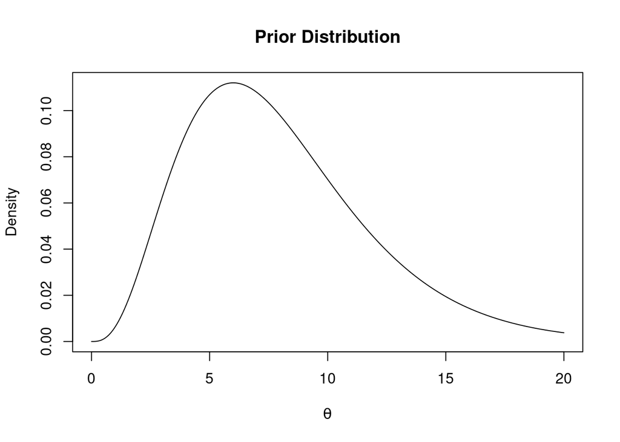

Note that this is a conjugate prior, so normally we would not use Stan, as it is a bit overboard for this problem. However, we are using this so that we can compare to what the actual posterior is. We will also look at a more complex example in a bit. First lets note the posterior distribution:

$$\theta|Y_1, \dots, Y_n \sim gamma(4+\sum_{i=1}^ny_i, 1/2+n)$$

# Stan Set up

To use `rstan` we need to create a `.stan` file that tells stan what our model is. You can create this in a text file. Below is an outline of what it involves:

```
data {
  // declaration of variables that are read in as data (Knowns)
}
transformed data {
   // can transform data here if needed
}
parameters {
   // declarations of parameter (Unknows)
}
transformed parameters {
   // can transform parameters here if needed
}
model {
   // declaration of prior distribution and likelihood
}
generated quantities {
   // prediction and diagnotics
}
```

You can read in more depth [here](https://mc-stan.org/docs/reference-manual/blocks.html)

For our simple model we will use the following `.stan` file:

```
// saved as pois.stan
data {
  int<lower=1> n;               // Number of samples
  int<lower=0> y[n];            // Sample vector
  real<lower=0> alpha;          // First gamma prior parameter
  real<lower=0> beta;           // Second gamma prior parameter
}
parameters {
   real<lower=0> theta;         // Our parameter of interest
}
model {
   theta ~ gamma(alpha, beta);  // Prior
   y ~ poisson(theta);          // Likelihood
}
```

# Running our Model

Below we can see the code for the data set up and running the model with `rstan`:

```r
# Generating the data
n <- 300
y <- rpois(n, 7)

# Running rstan sampler
stanDat <- list(n = n, y = y,
                alpha=4, beta=.5) # setting up data for stan
stanFit <- stan(file = "pois.stan", # Stan file
                data = stanDat, # Data
                warmup = 500, # Number of iteration to burn-in
                iter = 1500, # Total number of iterations
                chains = 4) # Number of chains to run
```

After running the sampler we can get some summaries of the posterior:

```r
stanFit
```

```
## Inference for Stan model: anon_model.
## 4 chains, each with iter=1500; warmup=500; thin=1;
## post-warmup draws per chain=1000, total post-warmup draws=4000.
##
##          mean se_mean   sd    2.5%     25%     50%     75%   97.5% n_eff Rhat
## theta    6.81    0.00 0.15    6.53    6.71    6.81    6.92    7.12  1508    1
## lp__  1881.94    0.02 0.73 1879.85 1881.78 1882.22 1882.41 1882.46  1988    1
##
## Samples were drawn using NUTS(diag_e) at Wed Jan 24 18:45:56 2024.
## For each parameter, n_eff is a crude measure of effective sample size,
## and Rhat is the potential scale reduction factor on split chains (at
## convergence, Rhat=1).
```

We can also get the entire sample with `extract(stanFit)`, this would be useful if you wanted to make unique plots. Though the `rstan` library has some built in plotting that is useful for a quick look at whats going on.

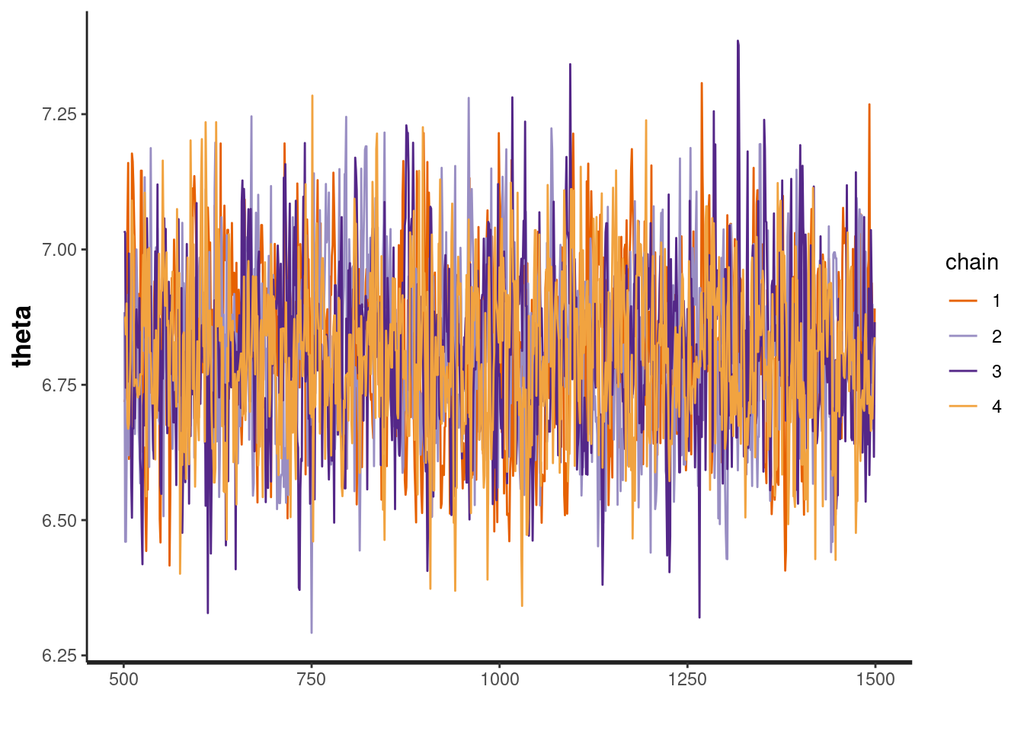

```r
traceplot(stanFit) # Check for convergence
```

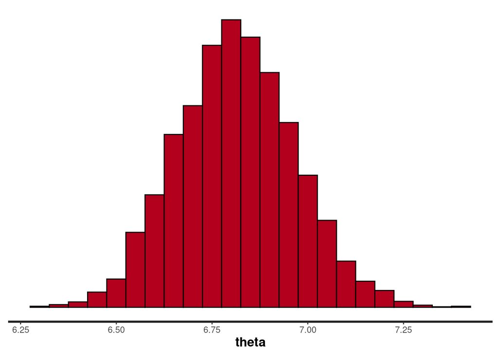

```r
stan_hist(stanFit, binwidth=.05)
```

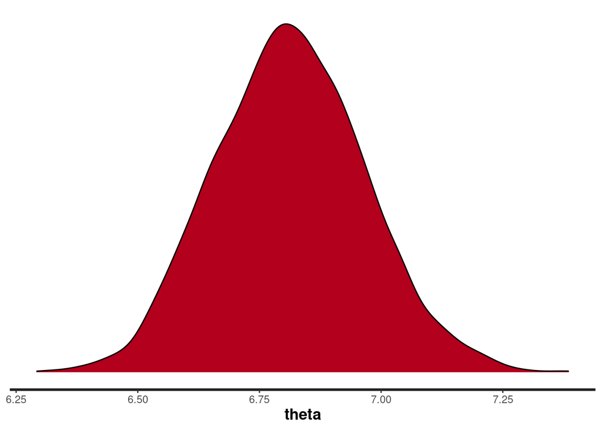

```r
stan_dens(stanFit)
```

Our actual posterior mean is 6.81, which is quite close to the estimated mean by the sampler. We can see the true posterior plotted below:

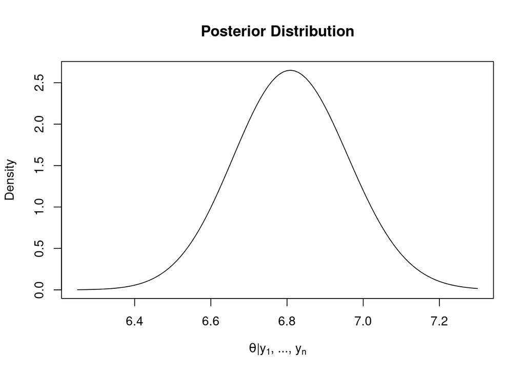

# Non-conjugate Example

This is a non-conjugate model, however we can still easily model with with Stan using the following:

```
// saved as norm.stan
data {
 int<lower = 1> n;     // Number of samples
 vector[n] y;          // Sample vector
 real df;              // Prior df
 real<lower=0> alpha;  // Prior scale
 real<lower=0> beta;   // Prior rate
}
parameters {
 real Theta;          // Mean unknow
 real <lower=0> Sig2; // variance unknow
}
model {
 // Priors:
 target += student_t_lpdf(Theta | df, 1, 1);    // lpdf is the log of the density
 target += gamma_lpdf(Sig2 | alpha, beta);

 // Likelihood:
 target += normal_lpdf(y | Theta, sqrt(Sig2));
}
```

Here are plots of the Priors:

[figure not shown]

Now we can set up the data and model to run:

```r
# Generating the data
n <- 500
y <- rnorm(n, 1.415, sqrt(2.718))

# Running rstan sampler
stanDat <- list(n = n, y = y, df=1,
                alpha=4, beta=1) # setting up data for stan
stanFit <- stan(file = "norm.stan", # Stan file
                data = stanDat, # Data
                warmup = 500, # Number of iteration to burn-in
                iter = 1500, # Total number of iterations
                chains = 4) # Number of chains to run
```

Again we can look at our summary output.

```r
stanFit
```

```
## Inference for Stan model: anon_model.
## 4 chains, each with iter=1500; warmup=500; thin=1;
## post-warmup draws per chain=1000, total post-warmup draws=4000.
##
##          mean se_mean   sd    2.5%     25%     50%     75%   97.5% n_eff Rhat
## Theta    1.41    0.00 0.08    1.26    1.36    1.42    1.46    1.56  3015    1
## Sig2     2.91    0.00 0.18    2.56    2.78    2.90    3.02    3.29  3200    1
## lp__  -976.43    0.02 1.01 -979.14 -976.78 -976.12 -975.71 -975.45  1877    1
##
## Samples were drawn using NUTS(diag_e) at Wed Jan 24 18:47:06 2024.
## For each parameter, n_eff is a crude measure of effective sample size,
## and Rhat is the potential scale reduction factor on split chains (at
## convergence, Rhat=1).
```

And we can look at the base plots again.

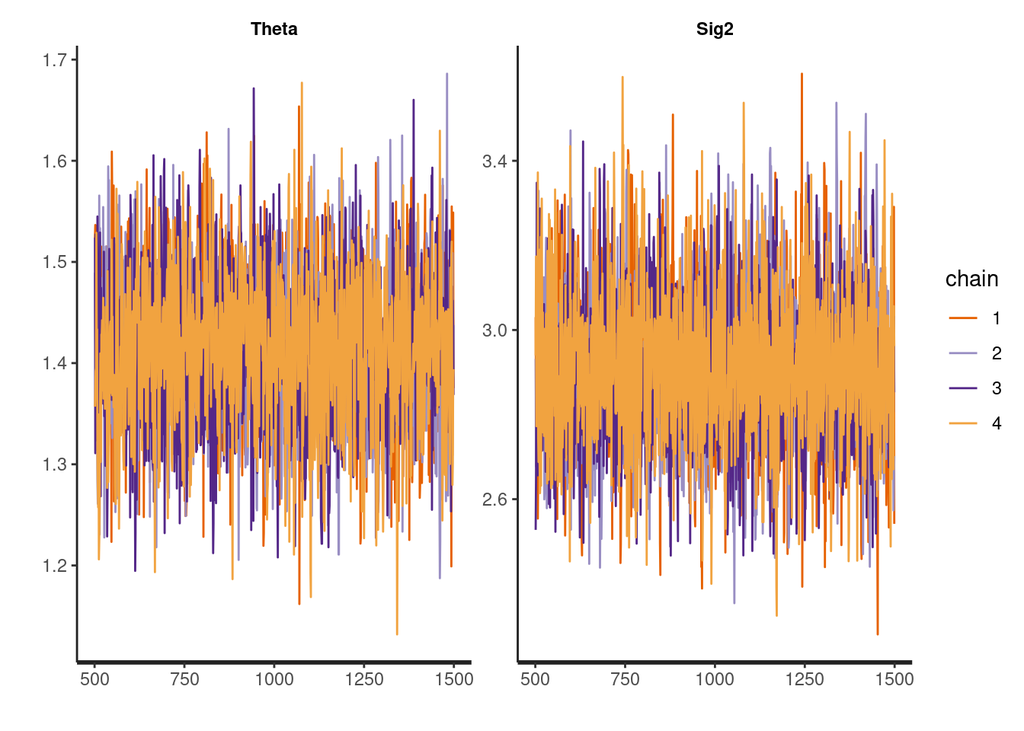

```r
traceplot(stanFit) # Check for convergence
```

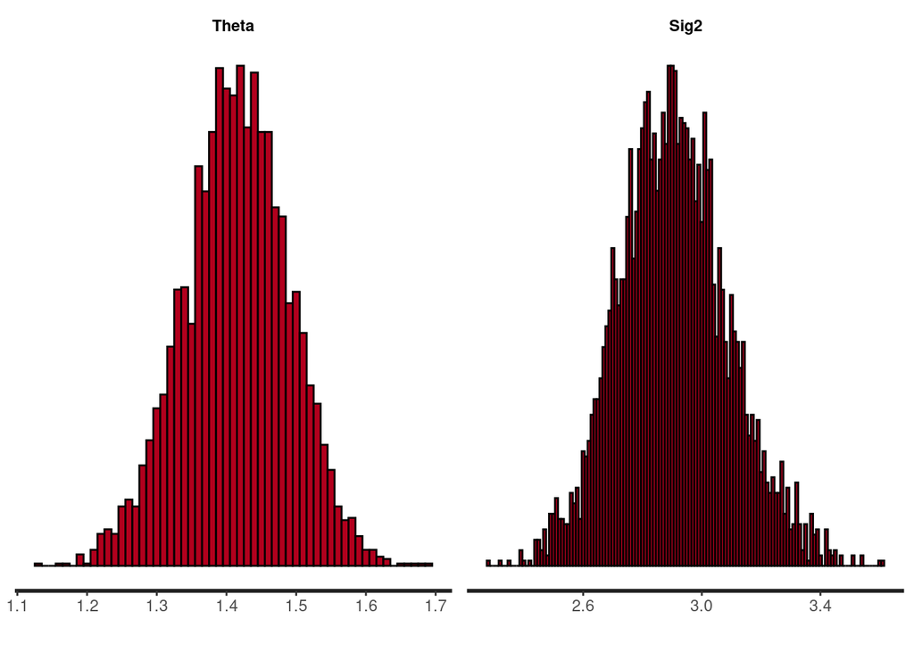

```r
stan_hist(stanFit, binwidth=.01)
```

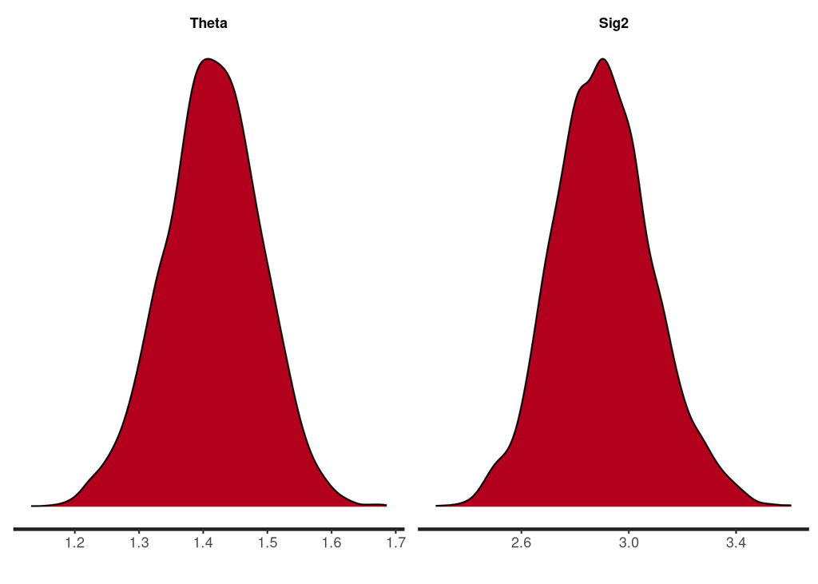

```r
stan_dens(stanFit)
```

# Random Effects Model

Now, we’ll explore a model with random effects for each group. We’ll write two Stan models: one using a loop and another using vectorization. After running both, we’ll compare their efficiency. The model is as follows:

$$\begin{aligned}
Y_{ij}|\alpha, \beta_i, \sigma &\overset{iid}{\sim} N(\alpha + \beta_i, \sigma) \\
\beta_i &\overset{iid}{\sim} N(0, \tau) \\
\alpha &\sim N(0, 10) \\
\sigma &\sim Inv-Gamma(3, 6) \\
\tau &\sim Inv-Gamma(3, 6)
\end{aligned}$$

where $Y_{ij}$ is the $j$th observation in the $i$th group, $\alpha$ is the overall mean, $\beta_i$ is the group-specific shift, $\sigma$ is the error standard deviation, and $\tau$ is the group effect standard deviation.

## Stan Models

### Model with Loop

The first Stan model uses a loop over groups.

```
// saved as random_effects_loop.stan
data {
  int<lower=1> N;            // Total number of observations
  int<lower=1> G;            // Number of groups
  int<lower=1, upper=G> group[N];  // Group index for each observation
  vector[N] y;               // Response variable
}
parameters {
  real alpha;                // Overall mean
  vector[G] beta;            // Group-specific shifts
  real<lower=0> sigma;       // Error standard deviation
  real<lower=0> tau;         // Group effect standard deviation
}
model {
  alpha ~ normal(0, 10);
  for (i in 1:G) {
    beta[i] ~ normal(0, tau);
  }
  sigma ~ inv_gamma(3, 6);
  tau ~ inv_gamma(3, 6);

  for (i in 1:N) {
    y[i] ~ normal(alpha + beta[group[i]], sigma);
  }
}
```

### Model with Vectorization

The second model uses vectorization for greater efficiency.

```
// saved as random_effects_vectorized.stan
data {
  int<lower=1> N;            // Total number of observations
  int<lower=1> G;            // Number of groups
  int<lower=1, upper=G> group[N];  // Group index for each observation
  vector[N] y;               // Response variable
}
parameters {
  real alpha;                // Overall mean
  vector[G] beta;            // Group-specific shifts
  real<lower=0> sigma;       // Error standard deviation
  real<lower=0> tau;         // Group effect standard deviation
}
model {
  alpha ~ normal(0, 10);
  beta ~ normal(0, tau);
  sigma ~ inv_gamma(3, 6);
  tau ~ inv_gamma(3, 6);

  y ~ normal(alpha + beta[group], sigma);
}
```

## Model Fitting and Comparison

Now, let’s fit both models in R and compare their run times.

```r
# simulate data
set.seed(1234)
Y <- rnorm(500, 20, 2)
groupShift <- rep(rnorm(5, 0, 3), each = 100)
Y <- Y + groupShift

# Data for Stan
stan_data <- list(N = 500, G = 5, group = rep(1:5, each = 100), y = Y)

# Fit the loop model
start_time <- Sys.time()
fit_loop <- stan(file = "random_effects_loop.stan", data = stan_data,
                 iter = 2000, warmup = 500, chains = 4)
end_time <- Sys.time()
time_loop <- end_time - start_time

# Fit the vectorized model
start_time <- Sys.time()
fit_vectorized <- stan(file = "random_effects_vectorized.stan", data = stan_data,
                       iter = 2000, warmup = 500, chains = 4)
end_time <- Sys.time()
time_vectorized <- end_time - start_time
```

Comparison of Run Times

| Model | Time |
| --- | --- |
| Loop | 31.40313 secs |
| Vectorized | 5.24548 secs |

This table provides a comparison of the efficiency gains achieved through vectorization in Stan. This is a simple example, but the efficiency gains can be much greater for more complex models.

## Results

Now, let’s look at the results of the vectorized model.

```r
fit_vectorized
```

```
## Inference for Stan model: anon_model.
## 4 chains, each with iter=2000; warmup=500; thin=1;
## post-warmup draws per chain=1500, total post-warmup draws=6000.
##
##            mean se_mean   sd    2.5%     25%     50%     75%   97.5% n_eff Rhat
## alpha     20.77    0.05 1.64   17.03   19.85   20.86   21.86   23.77   904    1
## beta[1]    1.86    0.05 1.65   -1.15    0.75    1.77    2.80    5.58   913    1
## beta[2]   -4.34    0.05 1.65   -7.36   -5.41   -4.41   -3.40   -0.67   910    1
## beta[3]    1.66    0.05 1.65   -1.37    0.56    1.58    2.59    5.38   920    1
## beta[4]   -1.11    0.05 1.65   -4.12   -2.20   -1.19   -0.17    2.60   914    1
## beta[5]    4.51    0.05 1.64    1.51    3.41    4.42    5.43    8.22   909    1
## sigma      2.07    0.00 0.06    1.95    2.03    2.07    2.11    2.20  3022    1
## tau        3.47    0.03 1.22    1.92    2.64    3.22    3.98    6.61  1468    1
## lp__    -635.53    0.05 2.04 -640.46 -636.67 -635.16 -634.04 -632.56  1777    1
##
## Samples were drawn using NUTS(diag_e) at Wed Jan 24 18:47:44 2024.
## For each parameter, n_eff is a crude measure of effective sample size,
## and Rhat is the potential scale reduction factor on split chains (at
## convergence, Rhat=1).
```

We can see the alpha is near 20, we can compare this to the true values betas too:

True Values of Beta

| Group | Beta |
| --- | --- |
| 1 | 2.954340 |
| 2 | -3.674214 |
| 3 | 2.129179 |
| 4 | -0.327660 |
| 5 | 5.347824 |

We can see that the estimated betas are close to the true values, and the credible intervals contain the true values.

# `rstanarm` Package

We will explore the use of `stan_glm`, a function from the `rstanarm` package, which allows for fitting Generalized Linear Models (GLMs). However, `rstanarm` has many other functions for fitting models, including `stan_gamm4` for fitting generalized additive mixed models, `stan_lmer` for fitting linear mixed effects models, and `stan_jm` for fitting joint models for longitudinal and time-to-event data.

## Model Specification

Our model can be expressed in the following form:

$$\begin{aligned}
Y_i|\beta, \sigma &\overset{iid}{\sim} Binomial(1, p_i) \\
p_i &:= logit(\beta_0 + \beta_1x_{i1} + \beta_2x_{i2}) \\
\beta_i &\sim N(0, 2.5^2)
\end{aligned}$$

where $Y_i$ is the response variable for the $i$th observation, $x_{i1}$ and $x_{i2}$ are the predictor variables for the $i$th observation, and $\beta_0$, $\beta_1$, and $\beta_2$ are the coefficients for the intercept and the two predictors, respectively.

## Fitting the Model with stan_glm

Now we will fit the model using `stan_glm` from the `rstanarm` package.

```r
library(rstanarm)

logit <- function(x) {
  1 / (1 + exp(-x))
}

# Generating logistic data
n <- 200  # number of observations
p <- 2    # number of predictors
X <- matrix(rnorm(n * p), n, p)  # predictor matrix
X <- cbind(1, X)  # add intercept
beta <- c(-1, 2.5, -1.5)  # true beta values

Y <- rbinom(n, 1, logit(X %*% beta))  # response vector
X <- X[, -1]  # remove intercept from predictor matrix

# Fit model with stan_glm
fit <- stan_glm(Y ~ X, data = data.frame(Y, X),
                family = binomial(link = "logit"),
                prior = normal(0, 2.5, autoscale = FALSE),
                prior_intercept = normal(0, 2.5, autoscale = FALSE),
                chains = 2, iter = 4000, warmup = 1000)
```

## Results and Comparison

Finally, let’s compare the estimated coefficients from the `stan_glm` model to our true beta values.

```r
summary(fit)
```

```
##
## Model Info:
##  function:     stan_glm
##  family:       binomial [logit]
##  formula:      Y ~ X
##  algorithm:    sampling
##  sample:       6000 (posterior sample size)
##  priors:       see help('prior_summary')
##  observations: 200
##  predictors:   3
##
## Estimates:
##               mean   sd   10%   50%   90%
## (Intercept) -1.2    0.3 -1.5  -1.2  -0.8
## X1           3.3    0.5  2.7   3.3   3.9
## X2          -2.1    0.3 -2.5  -2.0  -1.6
##
## Fit Diagnostics:
##            mean   sd   10%   50%   90%
## mean_PPD 0.5    0.0  0.4   0.4   0.5
##
## The mean_ppd is the sample average posterior predictive distribution of the outcome variable (for details see help('summary.stanreg')).
##
## MCMC diagnostics
##               mcse Rhat n_eff
## (Intercept)   0.0  1.0  3147
## X1            0.0  1.0  2968
## X2            0.0  1.0  3258
## mean_PPD      0.0  1.0  5398
## log-posterior 0.0  1.0  2457
##
## For each parameter, mcse is Monte Carlo standard error, n_eff is a crude measure of effective sample size, and Rhat is the potential scale reduction factor on split chains (at convergence Rhat=1).
```

```r
beta
```

```
## [1] -1.0  2.5 -1.5
```

# Resources and References

As you can image there is a lot more you can do. Below are some documentation links that should allow you to explore and gather what you need.

- [Stan Distributions](https://mc-stan.org/docs/functions-reference/continuous-distributions.html)
- [Stan Examples](https://mc-stan.org/docs/stan-users-guide/example-models.html#example-models.part)
- [rstan getting started](https://github.com/stan-dev/rstan/wiki/RStan-Getting-Started)
- [Stan blocks and general reference manual](https://mc-stan.org/docs/reference-manual/blocks.html)
- [rstanarm](https://mc-stan.org/rstanarm/)